# Convolution neural network beyond the human eyes

Case Study: “Transgender Face Recognition”  
* [0. Identify Business needs](#first-bullet)  
- [1. Import the needed libraries](#second-bullet)  
- [2. Load Data](#third-bullet)  
- [3. Base CNN Model](#fourth-bullet)  
- [4. Visualizing convnets learning](#fifth-bullet)  
- [5. Applying Dropout](#sixth-bullet)  
- [6. Data Augmentation and Dropout](#seventh-bullet)  
- [7. Optimizing The model with TensorBoard](#eigth-bullet)  
- [8. Transfer learning](#nineth-bullet)  
- [9. Extensions](#tenth-bullet)

# 0. Identify Business needs

Back to TOC

### Get overview about the problem and data availible

#### Gender Classification Dataset

###### Male Female image dataset

Collection methodology

The data was collected from the different sources in the internet including scraping the web. The data mostly consist of the image from imdb dataset. The IMDB dataset has almost 200k data which was carefully cleaned and seperated in the two different classes. After separating the data, the faces from the data were cropped and saved to different directory

Created on 2019-12-15 by Ashutosh Chauhan (Version 1)  
https://www.kaggle.com/cashutosh/gender-classification-dataset

# 1. Import the needed libraries

Back to TOC

```python
# Importing the Keras libraries and packages
from tensorflow.keras.models import Sequential
from tensorflow.keras.layers import Conv2D
from tensorflow.keras.layers import MaxPooling2D
from tensorflow.keras.layers import Flatten
from tensorflow.keras.layers import Dense
from tensorflow.keras import layers
from tensorflow.keras.layers import GlobalAveragePooling2D
from tensorflow.keras import backend as K

from tensorflow.keras.preprocessing.image import ImageDataGenerator
import os, shutil

import numpy as np
from sklearn.metrics import classification_report, confusion_matrix
import itertools

from tensorflow.keras import optimizers

import matplotlib.pyplot as plt
import scikitplot as skplt
import time
from keras.models import Model
from keras.models import load_model

# import callbacks
from tensorflow.keras.callbacks import EarlyStopping
from tensorflow.keras.callbacks import ModelCheckpoint
from tensorflow.keras.callbacks import TensorBoard
from tensorflow.keras.layers import Dropout
```

# 2. Load Data

Back to TOC

### Count how many pictures are in each training split (train/validation)

```python
print('total training male images:', len(os.listdir('dataset/Training/male')))
print('total training female images:', len(os.listdir('dataset/Training/female')))
print('total validation male images:', len(os.listdir('dataset/Validation/female')))
print('total validation female images:', len(os.listdir('dataset/Validation/female')))

print('total test male images:', len(os.listdir('dataset/Test/male')))
print('total test female images:', len(os.listdir('dataset/Test/female')))

print('total test transgender male images:', len(os.listdir('dataset/Test_trans/male')))
print('total test transgender female images:', len(os.listdir('dataset/Test_trans/female')))
```

```
total training male images: 21766
total training female images: 21243
total validation male images: 5841
total validation female images: 5841
total test male images: 2000
total test female images: 2000
total test transgender male images: 660
total test transgender female images: 660
```

# 3. Base CNN Model

Back to TOC

## 3.1 Building the network

```python
# Initialising the CNN
classifier1 = Sequential()

# Step 1 - Convolution
classifier1.add(Conv2D(32, (3, 3), input_shape = (64, 64, 3), activation = 'relu'))

# Step 2 - Pooling
classifier1.add(MaxPooling2D(pool_size = (2, 2)))

# Adding a second convolutional layer
classifier1.add(Conv2D(32, (3, 3), activation = 'relu'))
classifier1.add(MaxPooling2D(pool_size = (2, 2)))

# Step 3 - Flattening
classifier1.add(Flatten())

# Step 4 - Full connection
classifier1.add(Dense(units = 128, activation = 'relu'))
classifier1.add(Dense(units = 2, activation = 'softmax'))

classifier1.summary()
```

```
Model: "sequential"
_________________________________________________________________
Layer (type)                 Output Shape              Param #
=================================================================
conv2d (Conv2D)              (None, 62, 62, 32)        896
_________________________________________________________________
max_pooling2d (MaxPooling2D) (None, 31, 31, 32)        0
_________________________________________________________________
conv2d_1 (Conv2D)            (None, 29, 29, 32)        9248
_________________________________________________________________
max_pooling2d_1 (MaxPooling2 (None, 14, 14, 32)        0
_________________________________________________________________
flatten (Flatten)            (None, 6272)              0
_________________________________________________________________
dense (Dense)                (None, 128)               802944
_________________________________________________________________
dense_1 (Dense)              (None, 2)                 258
=================================================================
Total params: 813,346
Trainable params: 813,346
Non-trainable params: 0
_________________________________________________________________
```

```python
# Compiling the CNN
classifier1.compile(optimizer = 'adam', loss = 'categorical_crossentropy', metrics = ['accuracy'])
#classifier.compile(loss='categorical_crossentropy', optimizer = optimizers.Adam(lr=0.0004), metrics = ['acc'])
```

## 3.2 Data preprocessing

```python
train_datagen = ImageDataGenerator(rescale = 1./255)

test_datagen = ImageDataGenerator(rescale = 1./255)
```

```python
training_set = train_datagen.flow_from_directory('dataset/Training',
                                                 target_size = (64, 64),
                                                 batch_size = 32,
                                                 class_mode = 'categorical')

val_set = test_datagen.flow_from_directory('dataset/Validation',
                                            target_size = (64, 64),
                                            batch_size = 32,
                                            classes = ['female', 'male'])
                                            #class_mode = 'binary'
                                            # , shuffle=False

test_set = test_datagen.flow_from_directory('dataset/Test',
                                            target_size = (64, 64),
                                            batch_size = 32,
                                            classes = ['female', 'male'], shuffle=False)
                                            #class_mode = 'binary'

Test_trans_set = test_datagen.flow_from_directory('dataset/Test_trans',
                                            target_size = (64, 64),
                                            batch_size = 32,
                                            classes = ['female', 'male'], shuffle=False)
                                            #class_mode = 'binary'
```

```
Found 43009 images belonging to 2 classes.
Found 11649 images belonging to 2 classes.
Found 4000 images belonging to 2 classes.
Found 1320 images belonging to 2 classes.
```

## 3.3 Model fit

```python
history=classifier1.fit(training_set,
                         steps_per_epoch = 1344, # if batch_size=1 -> steps_per_epoch=8000
                         epochs = 20,
                         validation_data = val_set,
                         validation_steps = 50)
```

```python
# # save the model
# classifier1.save('Gender_Classifier_ver1_20.h5')
```

```python
# # Loading the model
# classifier1 = load_model('Gender_Classifier_ver1_20.h5')
# classifier1.summary()
```

[output not shown]

## 3.4 Displaying curves of loss and accuracy during training

```python
history_dict = history.history
history_dict.keys()
```

```
dict_keys(['loss', 'accuracy', 'val_loss', 'val_accuracy'])
```

```python
#history_dict = history.history
acc = history.history['accuracy']
val_acc = history.history['val_accuracy']
loss = history.history['loss']
val_loss = history.history['val_loss']

epochs = range(1, len(acc) + 1)
```

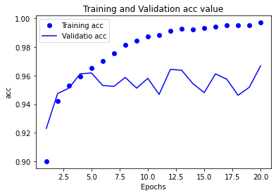

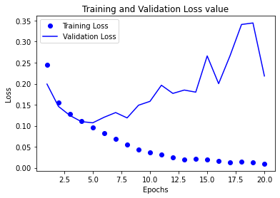

```python
plt.plot(epochs, acc, 'bo', label='Training acc')
plt.plot(epochs, val_acc, 'b', label='Validatio acc')
plt.title('Training and Validation acc value')
plt.xlabel('Epochs')
plt.ylabel('acc')
plt.legend()

plt.figure()

plt.plot(epochs, loss, 'bo', label='Training Loss')
plt.plot(epochs, val_loss, 'b', label='Validation Loss')
plt.title('Training and Validation Loss value')
plt.xlabel('Epochs')
plt.ylabel('Loss')
plt.legend()

plt.show()
```